# Introducción a la protección de datos personales en salud

Sabrina López

Jornadas Argentinas de Datos y Salud 2023 - 30 Noviembre de 2023

# Introducción a la protección de datos personales en salud

Este documento es una herramienta que forma parte del Taller de Introducción a la protección de datos personales en salud en las Jornadas Argentinas de Datos y Salud 2023.

Aquí vas a encontar algunas herramientas simples para explorar las posibilidades de procesamiento de los datos con el objetivo de resguardar la privacidad de sus titulares. De ningún modo es un compendio exhaustivo ni las estrategias seleccionadas son necesariamente las mejores.

Se presentarán alternativas en R y python. En la sección de créditos se incluye además un recurso con sugerencias para quienes trabajan con hojas de cálculo.

Para nuevas versiones de este material, no dudes en consultar proximamente en https://github.com/SLLDeC/. Esperamos que te sea de utilidad!

## Preparación

Como primer paso vamos a cargar las bibliotecas y datos necesarios. Es importante recordar que los ambientes de python y de R se van a encontrar separados.

```r
# Necesario para poder trabajar con python
library(reticulate)

# Necesario para manipular y analizar datos
library(tidyverse)

# Funciones para anonimizar datos
library(sdcMicro)
```

Cargamos los datos para trabajar en R:

```r
# Carga de la base de muestra para el ambiente de R
pacientes_muestra <- read_csv("data/muestra_pacientes_taller.csv",
                              locale = locale(encoding = "WINDOWS-1252"))
```

Cargamos los datos y bibliotecas para trabajar en python:

```python
# Para manipulación y análisis de datos
import pandas as pd

# Carga de la base de muestra para el ambiente de python
pacientes_muestra = pd.read_csv("data/muestra_pacientes_taller.csv", encoding='latin-1')
```

## Hashing

Se denomina así al proceso que transforma un dato en otra serie de caracteres de longitud fija, sin importar la longitud original de dicho dato. Existen diversos algoritmos que permiten hacer esta transformación. En el ejemplo, se toma como dato de entrada la columna ‘nombre_completo’ (que luego debería eliminarse), y se utiliza el algoritmo SHA-256 (Secure Hash Algorithm 2) para generar la columna ‘nombre_completo_hash’.

En R:

```r
### Se importa la biblioteca
library(openssl)

pacientes_muestra <- pacientes_muestra %>%
  mutate(nombre_completo_hash = sha256(nombre_completo))
```

En python:

```python
### Se importa la librería de hashing
import hashlib

### Como ejemplo se utiliza un hashing con sha256.
pacientes_muestra['nombre_completo_hash'] = pacientes_muestra['nombre_completo'].apply(lambda x: x.encode()).apply(hashlib.sha256).apply(lambda x: x.hexdigest())
```

Podemos comparar los resultados obtenidos mediante R y python:

```r
# Traigo al ambiente de R la variable en python
resultados_python <- py$pacientes_muestra

# Parametrizo la fila a comparar
fila = 4

out_r <- paste0('Datos en R:      ', pacientes_muestra$nombre_completo[fila],' -> ', pacientes_muestra$nombre_completo_hash[fila])

out_python <- paste0('\nDatos en python: ', resultados_python$nombre_completo[fila],' -> ', resultados_python$nombre_completo_hash[fila])
```

Como esperamos, los resultados coinciden

```r
cat(out_r,out_python)
```

```
## Datos en R:      Miguel Angel Fernandez -> 5cb2101e5a673947838782bb0bafff16a1c287f9792a597aae6c0aaa871354d7
## Datos en python: Miguel Angel Fernandez -> 5cb2101e5a673947838782bb0bafff16a1c287f9792a597aae6c0aaa871354d7
```

```r
# cat(out_python,out_r,"\n")
```

## Generalización

Consiste en reemplazar los valores puntuales por valores agrupados, menos específicos. Por ejemplo, una persona que aparece en los registros con la edad puntual de 38 años se la reemplaza por un intervalo que va desde los 30 a los 40 años. La columna ‘edad agrupada’ es el resultado del proceso de generalización a partir del valor ‘edad’ que es eliminado del conjunto de datos. Lo que se busca es reducir la granularidad de los datos, dificultando o incluso imposibilitando la recuperación de los valores puntuales asociados con un individuo.

En R:

```r
pacientes_muestra <- pacientes_muestra %>%
  mutate(edad_agrupada = cut(edad,
                              breaks = c(0, 18, 30, 45, 60, max(pacientes_muestra$edad)),
                              include.lowest = T,
                              labels = c('0-18', '19-30', '31-45', '46-60', '60+')))

# cuento el total de registros por categoría
totales_edad_agrupada_r <- pacientes_muestra %>%
  count(edad_agrupada, name = 'R')
```

En python:

```python
# límites de los grupos
bins = [0, 18, 30, 45, 60, 125]
#
# # nombre de las categorías
labels = ['0-18', '19-30', '31-45', '46-60', '60+']
#
pacientes_muestra['edad_agrupada'] = pd.cut(pacientes_muestra['edad'], bins=bins, labels=labels)
#
# # cuento el total de registros por categoría
totales_edad_agrupada_py = pacientes_muestra.groupby(['edad_agrupada'])['edad_agrupada'].count()
```

Comparamos los resultados obtenidos:

```r
# agrego el total de registros por cetgoría en python
totales_edad_agrupada_r['python'] =  py$totales_edad_agrupada_py

DT::datatable(totales_edad_agrupada_r,
              options = list(dom = 't'),
              rownames = FALSE)
```

| edad_agrupada | R | python |
| --- | --- | --- |
| 0-18 | 17304 | 17304 |
| 19-30 | 7624 | 7624 |
| 31-45 | 7801 | 7801 |
| 46-60 | 5929 | 5929 |
| 60+ | 7714 | 7714 |

## Supresión

La supresión consiste en remover los casos atípicos que por su baja frecuencia no pueden ser unidos en una clase de equivalencia ya sea porque son únicos en su clase (por ej. sólo una persona con edad en el rango de 50-59) o porque al generalizar implicaría ampliar una categoría de forma tal que se vuelve poco informativa (se amplía la categoría 40-49 a 40-60). El registro de la persona con el dato extrema (por ej. 58 años de edad), se remueve del conjunto de datos.

Para eso el primer paso es identificar los valores extremos, esto puede hacerse mediante cualquier estrategia conocida (por ej. rango intercuartílico). Por una cuestión de practicidad, vamos a reconocerlos con medidas resumen y box-plot, pero esto es muy dependiente del tipo de datos y el posterior uso que queramos hacer de ellos.

En R:

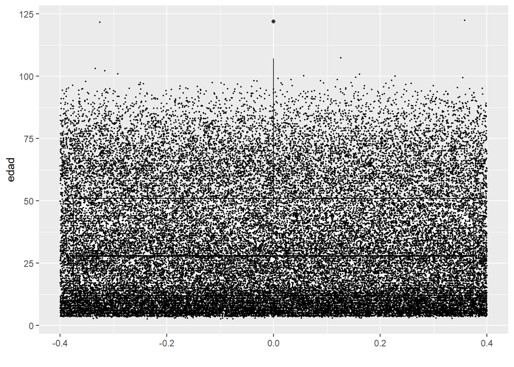

```r
ggplot(pacientes_muestra, aes(x=0, y=edad)) +
    geom_boxplot() +
    geom_jitter(color="black", size=0.4, alpha=0.9) +
    theme(
      legend.position="none",
      plot.title = element_text(size=11)
    ) +
    xlab("")
```

```r
pacientes_muestra_sup <- pacientes_muestra %>%
  filter(edad <= 100)

summary(pacientes_muestra_sup$edad)
```

```
##    Min. 1st Qu.  Median    Mean 3rd Qu.    Max.
##    3.00   12.00   28.00   32.78   51.00  100.00
```

En python:

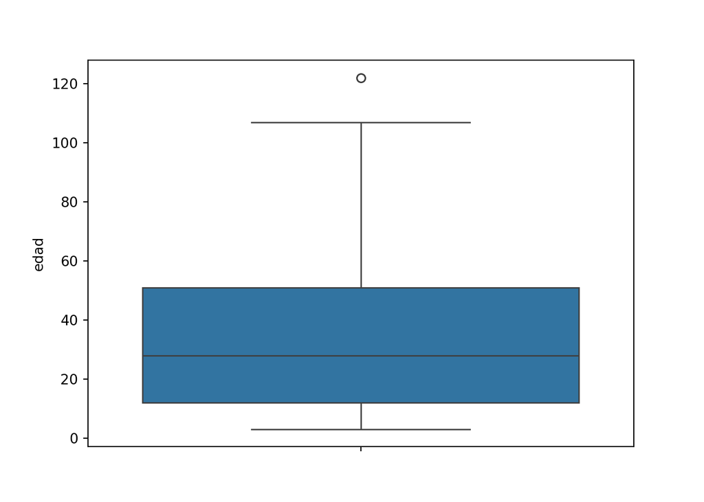

```python
# Box Plot
import seaborn as sns
sns.boxplot(pacientes_muestra['edad'])

# boxplot_py = sns.swarmplot(x=0, y='edad', data=pacientes_muestra, color="grey")

# boxplot_py
```

## Perturbación

Este método para anonimizar conjuntos de datos se puede aplicar a las entradas de datos numéricos, y consiste en reemplazar el valor de los atributos con valores aleatorios o partir de un listado, alterando los conjuntos de datos con un valor y una operación específicos. Este método modifica el conjunto de datos original mediante el uso de métodos de redondeo y ruido aleatorio.

En R:

```r
# Cargamos la biblioteca sdcMicro
library(sdcMicro)

# Parametrizamos el porcentaje de perturbación deseado
ruido = 10

pacientes_muestra['edad_per'] <- addNoise(pacientes_muestra['edad'], noise = ruido)$xm

# corregimos valores absurdos
pacientes_muestra <- pacientes_muestra %>%
  mutate(edad_per_corr = floor(abs(edad_per)))
```

En python:

```python
import numpy as np

pd.set_option('display.max_columns', None)

def add_noise(df, column, std = None):
    if std == None:
        std = df[column].std()

    withNoise = df[column].add(np.random.normal(0, std, df.shape[0]))
    copy = df.copy()
    copy[column] = withNoise
    return copy

perturbation = add_noise(pacientes_muestra, 'edad', std=10)
perturbation.head()
```

```
##    num_historia         nombre_completo fecha_nacimiento     provincia  \
## 0       43031.0            Ana Gonzalez       25/09/2009  Buenos Aires
## 1       26264.0   Juan Carlos Rodriguez       09/10/2009          Caba
## 2       64500.0             Maria Gomez       09/05/2009          Caba
## 3        8617.0  Miguel Angel Fernandez       20/09/1976  Buenos Aires
## 4        5849.0    Carlos Alberto Lopez       09/05/2009          Caba
##
##   departamento                           diagnostico       edad  \
## 0        merlo                   CALAMBRE Y ESPASMOS  26.213769
## 1    comuna 14     HIPOPIGMENTACION POSTINFLAMATORIA   3.374250
## 2     comuna 3          PROTOPORFIRIA ERITROPOYETICA  12.168527
## 3   la matanza  GRANULOMA TELANGIECTASICO DE LA BOCA  38.395213
## 4     comuna 1                               ASCITIS  -7.976242
##
##                                 nombre_completo_hash edad_agrupada
## 0  7dd69d129c865e0fbba8b215a9fb80022d7957e319fc33...          0-18
## 1  84e81c91e7d6950f51561760ef6a26751e7c9a0d55a703...          0-18
## 2  d2bd23ec6a2ca3720a9cc273955bf0d1449cf123ae5d7d...          0-18
## 3  5cb2101e5a673947838782bb0bafff16a1c287f9792a59...         46-60
## 4  6d0e19a7754b237de2f16a1727e58c71cb5d021ddab69c...          0-18
```

### Python

Reconocimiento de entidades nombradas y hashing:

- https://mostly.ai/blog/data-anonymization-in-python
- https://fund.ar/publicacion/guia-practica-para-la-anonimizacion-de-datos/

### R

Hashing:

https://cran.r-project.org/web/packages/openssl/vignettes/crypto_hashing.html

### Datasets

Datos abiertos - Argentina

- https://datos.gob.ar/dataset/otros-nombres-personas-fisicas
- ttps://datos.gob.ar/dataset/renaper-distribucion-apellidos-argentina

Datos abiertos - Colombia

- https://www.datos.gov.co/Ciencia-Tecnolog-a-e-Innovaci-n/Distribuci-n-de-Diagn-sticos-por-Edades-Dermatolog/ga8i-3ndm

### Para seguir explorando

- Reconocimiento de entidades nombradas en texto libre python https://github.com/instituciones-abiertas/anonimizacion-texto-libre
- Estrategias para hojas de cálculo https://www.excel-exercise.com/anonymise-your-data/
- Criterios de disociación de datos personales https://www.gub.uy/agencia-gobierno-electronico-sociedad-informacion-conocimiento/sites/agencia-gobierno-electronico-sociedad-informacion-conocimiento/files/documentos/noticias/11--criterios-de-disociacion-de-datos-personales.pdf